# Proyecto Final

Michelle Audirac

12/10/2017

EDA (R) Limpieza (R) Imputación (R o Python) Transformación (Python) Ingeniería de características (Python) Selección (Python) Filtrado (Python) Predicción con pipelines (multiples algoritmos) (Python) Medición entrega de reporte reproducible con instrucciones para ejecución

For this competition, you are tasked with categorizing shopping trip types based on the items that customers purchased. To give a few hypothetical examples of trip types: a customer may make a small daily dinner trip, a weekly large grocery trip, a trip to buy gifts for an upcoming holiday, or a seasonal trip to buy clothes.

Walmart has categorized the trips contained in this data into 38 distinct types using a proprietary method applied to an extended set of data. You are challenged to recreate this categorization/clustering with a more limited set of features. This could provide new and more robust ways to categorize trips.

The training set (train.csv) contains a large number of customer visits with the TripType included. You must predict the TripType for each customer visit in the test set (test.csv). Each visit may only have one TripType. You will not be provided with more information than what is given in the data (e.g. what the TripTypes represent or more product information).

The test set file is encrypted. You must complete this brief survey to receive the password.

Data fields

TripType - a categorical id representing the type of shopping trip the customer made. This is the ground truth that you are predicting. TripType_999 is an “other” category. VisitNumber - an id corresponding to a single trip by a single customer Weekday - the weekday of the trip Upc - the UPC number of the product purchased ScanCount - the number of the given item that was purchased. A negative value indicates a product return. DepartmentDescription - a high-level description of the item’s department FinelineNumber - a more refined category for each of the products, created by Walmart

## Carga

En esta sección cargamos los datasets `train`y `test` y generamos del dataset `total`.

**train**

- Cargamos los datos `train`

```r
train <- read.csv('../data/train.csv')
```

- Validamos la clase del objeto `train`

```r
class(train)
```

```
## [1] "data.frame"
```

- Observamos la estructura de `train`

```r
str(train)
```

```
## 'data.frame':    647054 obs. of  7 variables:
##  $ TripType             : int  999 30 30 26 26 26 26 26 26 26 ...
##  $ VisitNumber          : int  5 7 7 8 8 8 8 8 8 8 ...
##  $ Weekday              : Factor w/ 7 levels "Friday","Monday",..: 1 1 1 1 1 1 1 1 1 1 ...
##  $ Upc                  : num  6.81e+10 6.05e+10 7.41e+09 2.24e+09 2.01e+09 ...
##  $ ScanCount            : int  -1 1 1 2 2 2 1 1 1 -1 ...
##  $ DepartmentDescription: Factor w/ 69 levels "1-HR PHOTO","ACCESSORIES",..: 21 64 52 51 51 51 51 51 51 51 ...
##  $ FinelineNumber       : int  1000 8931 4504 3565 1017 1017 1017 2802 4501 3565 ...
```

- Modificamos la clase de algunas columnas de `train`

```r
train$TripType <- as.factor(train$TripType)
train$DepartmentDescription <- as.character(train$DepartmentDescription)
#train$VisitNumber <- as.factor(train$VisitNumber)
#train$Upc <- as.factor(train$Upc)
#train$FinelineNumber <- as.factor(train$FinelineNumber)
```

**test**

- Cargamos los datos `test`

```r
test <- read.csv('../data/test.csv')
```

- Validamos la clase del objeto `test`

```r
class(test)
```

```
## [1] "data.frame"
```

- Observamos la estructura de `test`

```r
str(test)
```

```
## 'data.frame':    653646 obs. of  6 variables:
##  $ VisitNumber          : int  1 1 1 1 2 2 2 2 3 3 ...
##  $ Weekday              : Factor w/ 7 levels "Friday","Monday",..: 1 1 1 1 1 1 1 1 1 1 ...
##  $ Upc                  : num  7.25e+10 1.71e+09 8.95e+10 8.85e+10 2.84e+09 ...
##  $ ScanCount            : int  1 1 1 1 1 1 1 1 1 -1 ...
##  $ DepartmentDescription: Factor w/ 68 levels "1-HR PHOTO","ACCESSORIES",..: 63 17 17 25 18 4 32 32 51 51 ...
##  $ FinelineNumber       : int  3002 1526 1431 3555 4408 5019 8023 8023 4504 4504 ...
```

- Modificamos la clase de algunas columnas de `test`

```r
test$DepartmentDescription <- as.character(test$DepartmentDescription)
```

**total**

- Concatenamos `test` y `train`

```r
total <- rbind(train[,-1], test)
```

- Observamos la estructura de `total`

```r
str(total)
```

```
## 'data.frame':    1300700 obs. of  6 variables:
##  $ VisitNumber          : int  5 7 7 8 8 8 8 8 8 8 ...
##  $ Weekday              : Factor w/ 7 levels "Friday","Monday",..: 1 1 1 1 1 1 1 1 1 1 ...
##  $ Upc                  : num  6.81e+10 6.05e+10 7.41e+09 2.24e+09 2.01e+09 ...
##  $ ScanCount            : int  -1 1 1 2 2 2 1 1 1 -1 ...
##  $ DepartmentDescription: chr  "FINANCIAL SERVICES" "SHOES" "PERSONAL CARE" "PAINT AND ACCESSORIES" ...
##  $ FinelineNumber       : int  1000 8931 4504 3565 1017 1017 1017 2802 4501 3565 ...
```

- Modificamos la clase de algunas columnas de `total`

```r
total$VisitNumber <- as.factor(total$VisitNumber)
total$DepartmentDescription <- as.factor(total$DepartmentDescription)
#total$Upc <- as.factor(total$Upc)
#total$FinelineNumber <- as.factor(total$FinelineNumber)
```

## Exploración univariada

En esta sección hacemos una exploración univarida de las columnas en todo el dataset (`test` y`train`).

### Campos vacíos

**train**

- Cuántos NAs hay por columna en el dataset `train`?

```r
apply(train, 2, function(x) sum(is.na(x)))
```

```
##              TripType           VisitNumber               Weekday
##                     0                     0                     0
##                   Upc             ScanCount DepartmentDescription
##                  4129                     0                     0
##        FinelineNumber
##                  4129
```

- Cuántos NULLs hay por columna en el dataset `train`?

```r
apply(train, 2, function(x) sum(is.null(x)))
```

```
##              TripType           VisitNumber               Weekday
##                     0                     0                     0
##                   Upc             ScanCount DepartmentDescription
##                     0                     0                     0
##        FinelineNumber
##                     0
```

**test**

- Cuántos NAs hay por columna en el dataset `test`?

```r
apply(test, 2, function(x) sum(is.na(x)))
```

```
##           VisitNumber               Weekday                   Upc
##                     0                     0                  3986
##             ScanCount DepartmentDescription        FinelineNumber
##                     0                     0                  3986
```

- Cuántos NULLs hay por columna en el dataset `test`?

```r
apply(test, 2, function(x) sum(is.null(x)))
```

```
##           VisitNumber               Weekday                   Upc
##                     0                     0                     0
##             ScanCount DepartmentDescription        FinelineNumber
##                     0                     0                     0
```

### TripType

`TripType` es una variable categórica

- Cuántas categorías tiene `TripType` en el dataset `train`?

```r
print(paste('numero de categorias:', length(levels(train$TripType))))
```

```
## [1] "numero de categorias: 38"
```

- Qué categorías y cuántas observaciones por categoría tiene `TripType` en el dataset `train`?

```r
print(summary(train$TripType))
```

```
##      3      4      5      6      7      8      9     12     14     15
##   6827    901  13836   3405  23199  22844  16820   2108     35   7147
##     18     19     20     21     22     23     24     25     26     27
##   2977   1188   3116   4032   3592    325  18015  27609   2507   4613
##     28     29     30     31     32     33     34     35     36     37
##   2664   2105   4861   1765  13843   9918   4751  12501  21990  38954
##     38     39     40     41     42     43     44    999
##  29565  95504 174164   5508  19468   6383  20424  17590
```

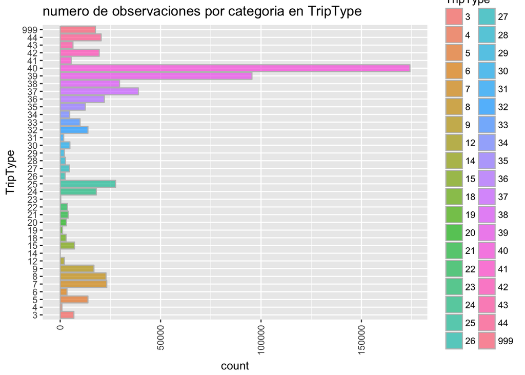

```r
ggplot(train, aes(TripType, fill = TripType)) +
  geom_bar(colour = 'grey', alpha = 0.7) +
  theme(axis.text.x = element_text(angle = 90, vjust = 0.5, hjust=1)) +
  labs(title = "numero de observaciones por categoria en TripType", x = "TripType", y = "count") +
  coord_flip()
```

### VisitNumber

`VisitNumber` es una variable categórica

- Cuántos `VisitNumber`s hay en los datasets?

```r
print(paste('numero de categorias:', length(levels(as.factor(train$VisitNumber)))))
```

```
## [1] "numero de categorias: 95674"
```

```r
print(paste('numero de categorias:', length(levels(as.factor(test$VisitNumber)))))
```

```
## [1] "numero de categorias: 95674"
```

```r
print(paste('numero de categorias:', length(levels(total$VisitNumber))))
```

```
## [1] "numero de categorias: 191348"
```

- Cuál es el resumen del número de observaciones por `VisitNumber` en el dataset `total`?

```r
summary(as.data.frame(table(total$VisitNumber))$Freq)
```

```
##    Min. 1st Qu.  Median    Mean 3rd Qu.    Max.
##   1.000   2.000   4.000   6.798   8.000 209.000
```

### Weekday

`Weekday` es una variable categórica

- Cuántas observaciones por `Weekday` hay en el dataset `total`?

```r
summary(total$Weekday)
```

```
##    Friday    Monday  Saturday    Sunday  Thursday   Tuesday Wednesday
##    191011    168304    246070    267208    138240    146271    143596
```

### Upc

`Upc` es una variable categórica

- Cuántas categorías tiene `Upc` en los datasets?

```r
print(paste('numero de categorias:', length(levels(as.factor(train$Upc)))))
```

```
## [1] "numero de categorias: 97714"
```

```r
print(paste('numero de categorias:', length(levels(as.factor(test$Upc)))))
```

```
## [1] "numero de categorias: 98147"
```

```r
print(paste('numero de categorias:', length(levels(as.factor(total$Upc)))))
```

```
## [1] "numero de categorias: 124693"
```

Vemos que hay demasiados `Upc` distintos. Además, existen varios `Upc` en `test` que no están en `train`.

### FinelineNumber

`FinelineNumber` es una variable categórica

- Cuántas categorías tiene `FinelineNumber` en los datasets?

```r
print(paste('numero de categorias:', length(levels(as.factor(train$FinelineNumber)))))
```

```
## [1] "numero de categorias: 5195"
```

```r
print(paste('numero de categorias:', length(levels(as.factor(test$FinelineNumber)))))
```

```
## [1] "numero de categorias: 5203"
```

```r
print(paste('numero de categorias:', length(levels(as.factor(total$FinelineNumber)))))
```

```
## [1] "numero de categorias: 5353"
```

Vemos que hay demasiados `FinelineNumber` distintos. Además, existen varios `FinelineNumber` en `test` que no están en `train`.

### DepartmentDescription

`DepartmentDescription` es una variable categórica

- Cuántas categorías tiene `DepartmentDescription` en los datasets?

```r
print(paste('numero de categorias:', length(levels(as.factor(train$DepartmentDescription)))))
```

```
## [1] "numero de categorias: 69"
```

```r
print(paste('numero de categorias:', length(levels(as.factor(test$DepartmentDescription)))))
```

```
## [1] "numero de categorias: 68"
```

```r
print(paste('numero de categorias:', length(levels(total$DepartmentDescription))))
```

```
## [1] "numero de categorias: 69"
```

- Qué categorías y cuántas observaciones por categoría tiene `DepartmentDescription` en el dataset `total`?

```r
summary(total$DepartmentDescription)
```

```
##                  1-HR PHOTO                 ACCESSORIES
##                         788                        2738
##                  AUTOMOTIVE                      BAKERY
##                       10873                       14333
##             BATH AND SHOWER                      BEAUTY
##                        9247                       30088
##                     BEDDING         BOOKS AND MAGAZINES
##                        4510                        1901
##                   BOYS WEAR            BRAS & SHAPEWEAR
##                        7778                        4054
##        CAMERAS AND SUPPLIES     CANDY, TOBACCO, COOKIES
##                         468                       20118
##                 CELEBRATION                  COMM BREAD
##                       17333                       30932
##              CONCEPT STORES               COOK AND DINE
##                          84                       15388
##                       DAIRY                 DSD GROCERY
##                       88644                      137192
##                 ELECTRONICS          FABRICS AND CRAFTS
##                        6551                       10221
##          FINANCIAL SERVICES                FROZEN FOODS
##                       21580                       42991
##                   FURNITURE  GIRLS WEAR, 4-6X  AND 7-14
##                         921                        9144
##           GROCERY DRY GOODS                    HARDWARE
##                      142737                        9798
##      HEALTH AND BEAUTY AIDS                  HOME DECOR
##                           2                        8236
##             HOME MANAGEMENT     HORTICULTURE AND ACCESS
##                       12646                        5933
##    HOUSEHOLD CHEMICALS/SUPP       HOUSEHOLD PAPER GOODS
##                       49482                       31916
##         IMPULSE MERCHANDISE              INFANT APPAREL
##                       57153                       12610
## INFANT CONSUMABLE HARDLINES      JEWELRY AND SUNGLASSES
##                       21316                        5003
##                LADIES SOCKS                  LADIESWEAR
##                        1537                       17740
##       LARGE HOUSEHOLD GOODS             LAWN AND GARDEN
##                         180                       10790
```

[output cut: 15 more lines]

```
##                        5706                        1355
##          PLUS AND MATERNITY             PRE PACKED DELI
##                        1235                       18328
##                     PRODUCE                     SEAFOOD
##                      102043                        4058
##                    SEASONAL                SERVICE DELI
##                          76                       20176
##               SHEER HOSIERY                       SHOES
##                         948                       12313
##       SLEEPWEAR/FOUNDATIONS              SPORTING GOODS
##                        4839                       10118
##          SWIMWEAR/OUTERWEAR                        TOYS
##                        1730                       12242
##                    WIRELESS
##                        3708
```

Antes no identificamos NULLs en ninguna columna, pero existe una categoría ‘NULL’ en `DepartmentDescription`.

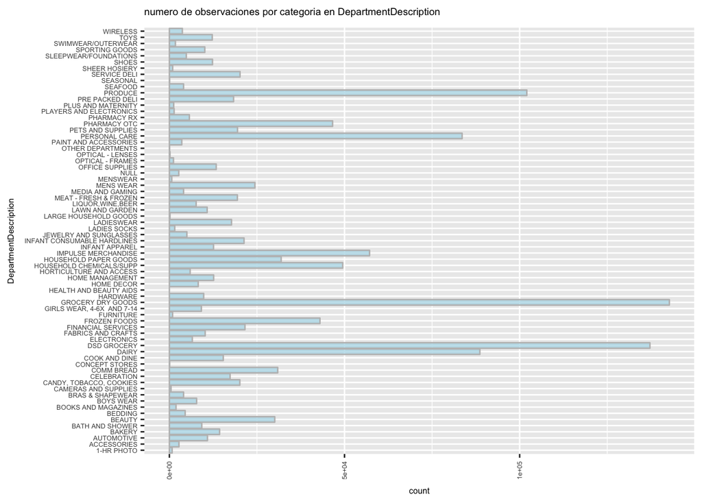

```r
ggplot(total, aes(DepartmentDescription)) +
  geom_bar(colour = 'grey', fill = 'lightblue', alpha = 0.7) +
  theme(axis.text.x = element_text(angle = 90, vjust = 0.5, hjust=1)) +
  theme(text = element_text(size = 6)) +
  labs(title = "numero de observaciones por categoria en DepartmentDescription", x = "DepartmentDescription", y = "count") +
  coord_flip()
```

### ScanCount

`ScanCount` es una variable numérica

- Cuál es el resumen de `ScanCount` en el dataset `total`?

```r
summary(total$ScanCount)
```

```
##    Min. 1st Qu.  Median    Mean 3rd Qu.    Max.
## -21.000   1.000   1.000   1.109   1.000  71.000
```

- Cuál es el histograma de `ScanCount` en el dataset `total`?

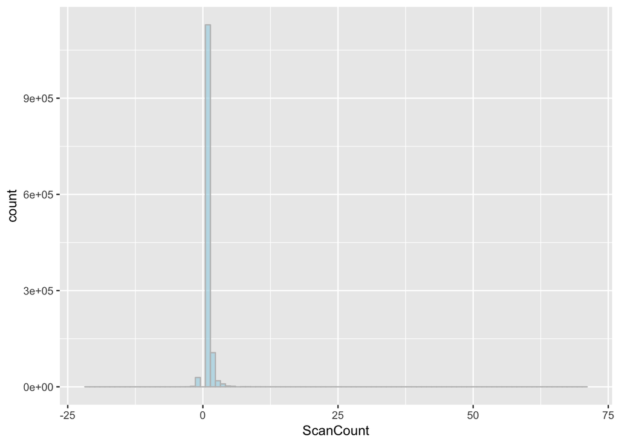

```r
ggplot(total, aes(x = ScanCount)) +
  geom_histogram(colour = 'grey', fill = 'lightblue', alpha = 0.7, bins = 100)
```

## Preparación

En esta sección preparamos los datos para hacer la exploración bivariada.

```r
total_prep <- as_tibble(total)
total_prep %<>%
  mutate(VisitNumber = as.factor(VisitNumber)) %>%
  mutate(ScanCount = as.numeric(ScanCount)) %>%
  mutate(Upc = as.factor(Upc)) %>%
  mutate(FinelineNumber = as.factor(FinelineNumber)) %>%
  mutate(DepartmentDescription = as.factor(DepartmentDescription))

glimpse(total_prep)
```

```
## Observations: 1,300,700
## Variables: 6
## $ VisitNumber           <fctr> 5, 7, 7, 8, 8, 8, 8, 8, 8, 8, 8, 8, 8, ...
## $ Weekday               <fctr> Friday, Friday, Friday, Friday, Friday,...
## $ Upc                   <fctr> 68113152929, 60538815980, 7410811099, 2...
## $ ScanCount             <dbl> -1, 1, 1, 2, 2, 2, 1, 1, 1, -1, 1, 2, 1,...
## $ DepartmentDescription <fctr> FINANCIAL SERVICES, SHOES, PERSONAL CAR...
## $ FinelineNumber        <fctr> 1000, 8931, 4504, 3565, 1017, 1017, 101...
```

```r
saveRDS(total_prep, '../data/total_prep.RDS')
```

```r
train_prep <- as_tibble(train)

train_prep %<>%
  mutate(VisitNumber = factor(VisitNumber, levels(total_prep$VisitNumber))) %>%
  mutate(ScanCount = as.numeric(ScanCount)) %>%
  mutate(Upc = factor(Upc, levels(total_prep$Upc))) %>%
  mutate(FinelineNumber = factor(FinelineNumber, levels(total_prep$FinelineNumber))) %>%
  mutate(DepartmentDescription = factor(DepartmentDescription, levels(total_prep$DepartmentDescription)))

glimpse(train_prep)
```

```
## Observations: 647,054
## Variables: 7
## $ TripType              <fctr> 999, 30, 30, 26, 26, 26, 26, 26, 26, 26...
## $ VisitNumber           <fctr> 5, 7, 7, 8, 8, 8, 8, 8, 8, 8, 8, 8, 8, ...
## $ Weekday               <fctr> Friday, Friday, Friday, Friday, Friday,...
## $ Upc                   <fctr> 68113152929, 60538815980, 7410811099, 2...
## $ ScanCount             <dbl> -1, 1, 1, 2, 2, 2, 1, 1, 1, -1, 1, 2, 1,...
## $ DepartmentDescription <fctr> FINANCIAL SERVICES, SHOES, PERSONAL CAR...
## $ FinelineNumber        <fctr> 1000, 8931, 4504, 3565, 1017, 1017, 101...
```

```r
saveRDS(train_prep, '../data/train_prep.RDS')
```

```r
test_prep <- as_tibble(test)

test_prep %<>%
  mutate(VisitNumber = factor(VisitNumber, levels(total_prep$VisitNumber))) %>%
  mutate(ScanCount = as.numeric(ScanCount)) %>%
  mutate(Upc = factor(Upc, levels(total_prep$Upc))) %>%
  mutate(FinelineNumber = factor(FinelineNumber, levels(total_prep$FinelineNumber))) %>%
  mutate(DepartmentDescription = factor(DepartmentDescription, levels(total_prep$DepartmentDescription)))

glimpse(test_prep)
```

```
## Observations: 653,646
## Variables: 6
## $ VisitNumber           <fctr> 1, 1, 1, 1, 2, 2, 2, 2, 3, 3, 4, 6, 6, ...
## $ Weekday               <fctr> Friday, Friday, Friday, Friday, Friday,...
## $ Upc                   <fctr> 72503389714, 1707710732, 89470001026, 8...
## $ ScanCount             <dbl> 1, 1, 1, 1, 1, 1, 1, 1, 1, -1, 1, 1, -1,...
## $ DepartmentDescription <fctr> SHOES, DAIRY, DAIRY, GROCERY DRY GOODS,...
## $ FinelineNumber        <fctr> 3002, 1526, 1431, 3555, 4408, 5019, 802...
```

```r
saveRDS(test_prep, '../data/test_prep.RDS')
```